# Exploring Crime Trends in Los Angeles: An Analysis of Recent Data

# **Introduction**

For this project,I will be analyzing the Los Angeles Police Department’s “Crime Data from 2020 to Present” dataset(LAPD).The dataset contains information on crimes reported in Los Angeles from January 2020 to the present.The data is updated daily and is available via the Los Angeles Open Data portal.I intend to investigate patterns and trends in crime data, such as the types of crimes committed,their locations, and whether there are any significant changes in crime rates over time.

# Loading necessary Packages

```r
library(dplyr)
library(ggplot2)
library(lubridate)
library(tidyverse)
library(dygraphs)
library(leaflet)
```

# Importing Data

```r
# Loading and Reading data into a dataframe
crime_data <- read_csv("C:/Users/bindh/Downloads/Crime_Data_from_2020_to_Present.csv")
crime_data
```

| DR_NO | Date Rptd | DATE OCC | TIME OCC | AREA | AREA NAME | Rpt Dist No | Part 1-2 | Crm Cd | Crm Cd Desc | Mocodes | Vict Age | Vict Sex | Vict Descent | Premis Cd | Premis Desc | Weapon Used Cd | Weapon Desc | Status | Status Desc | Crm Cd 1 | Crm Cd 2 | Crm Cd 3 | Crm Cd 4 | LOCATION | Cross Street | LAT | LON |
| --- | --- | --- | --- | --- | --- | --- | --- | --- | --- | --- | --- | --- | --- | --- | --- | --- | --- | --- | --- | --- | --- | --- | --- | --- | --- | --- | --- |
| 010304468 | 01/08/2020 12:00:00 AM | 01/08/2020 12:00:00 AM | 2230 | 03 | Southwest | 0377 | 2 | 624 | BATTERY - SIMPLE ASSAULT | 0444 0913 | 36 | F | B | 501 | SINGLE FAMILY DWELLING | 400 | STRONG-ARM (HANDS, FIST, FEET OR BODILY FORCE) | AO | Adult Other | 624 | NA | NA | NA | 1100 W 39TH PL | NA | 34.0141 | -118.2978 |
| 190101086 | 01/02/2020 12:00:00 AM | 01/01/2020 12:00:00 AM | 0330 | 01 | Central | 0163 | 2 | 624 | BATTERY - SIMPLE ASSAULT | 0416 1822 1414 | 25 | M | H | 102 | SIDEWALK | 500 | UNKNOWN WEAPON/OTHER WEAPON | IC | Invest Cont | 624 | NA | NA | NA | 700 S HILL ST | NA | 34.0459 | -118.2545 |
| 200110444 | 04/14/2020 12:00:00 AM | 02/13/2020 12:00:00 AM | 1200 | 01 | Central | 0155 | 2 | 845 | SEX OFFENDER REGISTRANT OUT OF COMPLIANCE | 1501 | 0 | X | X | 726 | POLICE FACILITY | NA | NA | AA | Adult Arrest | 845 | NA | NA | NA | 200 E 6TH ST | NA | 34.0448 | -118.2474 |
| 191501505 | 01/01/2020 12:00:00 AM | 01/01/2020 12:00:00 AM | 1730 | 15 | N Hollywood | 1543 | 2 | 745 | VANDALISM - MISDEAMEANOR ($399 OR UNDER) | 0329 1402 | 76 | F | W | 502 | MULTI-UNIT DWELLING (APARTMENT, DUPLEX, ETC) | NA | NA | IC | Invest Cont | 745 | 998 | NA | NA | 5400 CORTEEN PL | NA | 34.1685 | -118.4019 |
| 191921269 | 01/01/2020 12:00:00 AM | 01/01/2020 12:00:00 AM | 0415 | 19 | Mission | 1998 | 2 | 740 | VANDALISM - FELONY ($400 & OVER, ALL CHURCH VANDALISMS) | 0329 | 31 | X | X | 409 | BEAUTY SUPPLY STORE | NA | NA | IC | Invest Cont | 740 | NA | NA | NA | 14400 TITUS ST | NA | 34.2198 | -118.4468 |
| 200100501 | 01/02/2020 12:00:00 AM | 01/01/2020 12:00:00 AM | 0030 | 01 | Central | 0163 | 1 | 121 | RAPE, FORCIBLE | 0413 1822 1262 1415 | 25 | F | H | 735 | NIGHT CLUB (OPEN EVENINGS ONLY) | 500 | UNKNOWN WEAPON/OTHER WEAPON | IC | Invest Cont | 121 | 998 | NA | NA | 700 S BROADWAY | NA | 34.0452 | -118.2534 |
| 200100502 | 01/02/2020 12:00:00 AM | 01/02/2020 12:00:00 AM | 1315 | 01 | Central | 0161 | 1 | 442 | SHOPLIFTING - PETTY THEFT ($950 & UNDER) | 1402 2004 0344 0387 | 23 | M | H | 404 | DEPARTMENT STORE | NA | NA | IC | Invest Cont | 442 | 998 | NA | NA | 700 S FIGUEROA ST | NA | 34.0483 | -118.2631 |
| 200100504 | 01/04/2020 12:00:00 AM | 01/04/2020 12:00:00 AM | 0040 | 01 | Central | 0155 | 2 | 946 | OTHER MISCELLANEOUS CRIME | 1402 0392 | 0 | X | X | 726 | POLICE FACILITY | NA | NA | IC | Invest Cont | 946 | 998 | NA | NA | 200 E 6TH ST | NA | 34.0448 | -118.2474 |
| 200100507 | 01/04/2020 12:00:00 AM | 01/04/2020 12:00:00 AM | 0200 | 01 | Central | 0101 | 1 | 341 | THEFT-GRAND ($950.01 & OVER)EXCPT,GUNS,FOWL,LIVESTK,PROD | 1822 0344 1402 | 23 | M | B | 502 | MULTI-UNIT DWELLING (APARTMENT, DUPLEX, ETC) | NA | NA | IC | Invest Cont | 341 | 998 | NA | NA | 700 BERNARD ST | NA | 34.0677 | -118.2398 |
| 201710201 | 06/19/2020 12:00:00 AM | 05/26/2020 12:00:00 AM | 1925 | 17 | Devonshire | 1708 | 1 | 341 | THEFT-GRAND ($950.01 & OVER)EXCPT,GUNS,FOWL,LIVESTK,PROD | 1300 0202 0378 0325 | 0 | X | X | 203 | OTHER BUSINESS | NA | NA | AO | Adult Other | 341 | NA | NA | NA | 11900 BALBOA BL | NA | 34.2864 | -118.5021 |

[output cut: 990 more lines]

# **Data Description**

The data is collected by the Los Angeles Police Department (LAPD) and is updated daily.

The types of crimes included in the dataset range from property crimes, such as burglary and theft,to violent crimes,such as assault and homicide.The data is organized by reporting district, which is a geographical area designated by the LAPD.

The purpose of this dataset is to provide transparency and accountability in law enforcement and to help researchers and policymakers understand crime patterns in the city of Los Angeles. However,it’s important to note that the dataset may not include all crimes committed in the city, as some crimes may go unreported.

```r
summary(crime_data)
```

```
    DR_NO            Date Rptd           DATE OCC           TIME OCC             AREA
 Length:690454      Length:690454      Length:690454      Length:690454      Length:690454
 Class :character   Class :character   Class :character   Class :character   Class :character
 Mode  :character   Mode  :character   Mode  :character   Mode  :character   Mode  :character




  AREA NAME         Rpt Dist No           Part 1-2         Crm Cd      Crm Cd Desc
 Length:690454      Length:690454      Min.   :1.000   Min.   :110.0   Length:690454
 Class :character   Class :character   1st Qu.:1.000   1st Qu.:330.0   Class :character
 Mode  :character   Mode  :character   Median :1.000   Median :442.0   Mode  :character
                                       Mean   :1.416   Mean   :500.6
                                       3rd Qu.:2.000   3rd Qu.:626.0
                                       Max.   :2.000   Max.   :956.0

   Mocodes             Vict Age        Vict Sex         Vict Descent         Premis Cd
 Length:690454      Min.   : -2.00   Length:690454      Length:690454      Min.   :101.0
 Class :character   1st Qu.: 12.00   Class :character   Class :character   1st Qu.:101.0
 Mode  :character   Median : 31.00   Mode  :character   Mode  :character   Median :203.0
                    Mean   : 29.98                                         Mean   :304.9
                    3rd Qu.: 45.00                                         3rd Qu.:501.0
                    Max.   :120.00                                         Max.   :971.0
                                                                           NA's   :8
 Premis Desc        Weapon Used Cd   Weapon Desc           Status          Status Desc
 Length:690454      Min.   :101.0    Length:690454      Length:690454      Length:690454
 Class :character   1st Qu.:308.0    Class :character   Class :character   Class :character
 Mode  :character   Median :400.0    Mode  :character   Mode  :character   Mode  :character
                    Mean   :362.2
                    3rd Qu.:400.0
                    Max.   :516.0
                    NA's   :450488
    Crm Cd 1        Crm Cd 2         Crm Cd 3      Crm Cd 4         LOCATION         Cross Street
 Min.   :110.0   Min.   :210.0    Min.   :434.0    Mode:logical   Length:690454      Length:690454
 1st Qu.:330.0   1st Qu.:998.0    1st Qu.:998.0    NA's:690454    Class :character   Class :character
 Median :442.0   Median :998.0    Median :998.0                   Mode  :character   Mode  :character
 Mean   :500.3   Mean   :956.7    Mean   :983.3
 3rd Qu.:626.0   3rd Qu.:998.0    3rd Qu.:998.0
 Max.   :956.0   Max.   :999.0    Max.   :999.0
 NA's   :9       NA's   :638918   NA's   :688721
      LAT             LON
 Min.   : 0.00   Min.   :-118.7
 1st Qu.:34.01   1st Qu.:-118.4
 Median :34.06   Median :-118.3
 Mean   :33.96   Mean   :-118.0
 3rd Qu.:34.16   3rd Qu.:-118.3
 Max.   :34.33   Max.   :   0.0
```

```r
sum(is.na(crime_data))
```

```
[1] 3773604
```

```r
# Exploring the structure of the data
str(crime_data)
```

```
spc_tbl_ [690,454 × 28] (S3: spec_tbl_df/tbl_df/tbl/data.frame)
 $ DR_NO         : chr [1:690454] "010304468" "190101086" "200110444" "191501505" ...
 $ Date Rptd     : chr [1:690454] "01/08/2020 12:00:00 AM" "01/02/2020 12:00:00 AM" "04/14/2020 12:00:00 AM" "01/01/2020 12:00:00 AM" ...
 $ DATE OCC      : chr [1:690454] "01/08/2020 12:00:00 AM" "01/01/2020 12:00:00 AM" "02/13/2020 12:00:00 AM" "01/01/2020 12:00:00 AM" ...
 $ TIME OCC      : chr [1:690454] "2230" "0330" "1200" "1730" ...
 $ AREA          : chr [1:690454] "03" "01" "01" "15" ...
 $ AREA NAME     : chr [1:690454] "Southwest" "Central" "Central" "N Hollywood" ...
 $ Rpt Dist No   : chr [1:690454] "0377" "0163" "0155" "1543" ...
 $ Part 1-2      : num [1:690454] 2 2 2 2 2 1 1 2 1 1 ...
 $ Crm Cd        : num [1:690454] 624 624 845 745 740 121 442 946 341 341 ...
 $ Crm Cd Desc   : chr [1:690454] "BATTERY - SIMPLE ASSAULT" "BATTERY - SIMPLE ASSAULT" "SEX OFFENDER REGISTRANT OUT OF COMPLIANCE" "VANDALISM - MISDEAMEANOR ($399 OR UNDER)" ...
 $ Mocodes       : chr [1:690454] "0444 0913" "0416 1822 1414" "1501" "0329 1402" ...
 $ Vict Age      : num [1:690454] 36 25 0 76 31 25 23 0 23 0 ...
 $ Vict Sex      : chr [1:690454] "F" "M" "X" "F" ...
 $ Vict Descent  : chr [1:690454] "B" "H" "X" "W" ...
 $ Premis Cd     : num [1:690454] 501 102 726 502 409 735 404 726 502 203 ...
 $ Premis Desc   : chr [1:690454] "SINGLE FAMILY DWELLING" "SIDEWALK" "POLICE FACILITY" "MULTI-UNIT DWELLING (APARTMENT, DUPLEX, ETC)" ...
 $ Weapon Used Cd: num [1:690454] 400 500 NA NA NA 500 NA NA NA NA ...
 $ Weapon Desc   : chr [1:690454] "STRONG-ARM (HANDS, FIST, FEET OR BODILY FORCE)" "UNKNOWN WEAPON/OTHER WEAPON" NA NA ...
 $ Status        : chr [1:690454] "AO" "IC" "AA" "IC" ...
 $ Status Desc   : chr [1:690454] "Adult Other" "Invest Cont" "Adult Arrest" "Invest Cont" ...
 $ Crm Cd 1      : num [1:690454] 624 624 845 745 740 121 442 946 341 341 ...
 $ Crm Cd 2      : num [1:690454] NA NA NA 998 NA 998 998 998 998 NA ...
 $ Crm Cd 3      : num [1:690454] NA NA NA NA NA NA NA NA NA NA ...
 $ Crm Cd 4      : logi [1:690454] NA NA NA NA NA NA ...
 $ LOCATION      : chr [1:690454] "1100 W  39TH                         PL" "700 S  HILL                         ST" "200 E  6TH                          ST" "5400    CORTEEN                      PL" ...
 $ Cross Street  : chr [1:690454] NA NA NA NA ...
 $ LAT           : num [1:690454] 34 34 34 34.2 34.2 ...
 $ LON           : num [1:690454] -118 -118 -118 -118 -118 ...
 - attr(*, "spec")=
  .. cols(
  ..   DR_NO = col_character(),
  ..   `Date Rptd` = col_character(),
  ..   `DATE OCC` = col_character(),
  ..   `TIME OCC` = col_character(),
  ..   AREA = col_character(),
  ..   `AREA NAME` = col_character(),
  ..   `Rpt Dist No` = col_character(),
  ..   `Part 1-2` = col_double(),
  ..   `Crm Cd` = col_double(),
  ..   `Crm Cd Desc` = col_character(),
  ..   Mocodes = col_character(),
  ..   `Vict Age` = col_double(),
  ..   `Vict Sex` = col_character(),
  ..   `Vict Descent` = col_character(),
  ..   `Premis Cd` = col_double(),
  ..   `Premis Desc` = col_character(),
  ..   `Weapon Used Cd` = col_double(),
  ..   `Weapon Desc` = col_character(),
  ..   Status = col_character(),
  ..   `Status Desc` = col_character(),
  ..   `Crm Cd 1` = col_double(),
  ..   `Crm Cd 2` = col_double(),
  ..   `Crm Cd 3` = col_double(),
  ..   `Crm Cd 4` = col_logical(),
  ..   LOCATION = col_character(),
  ..   `Cross Street` = col_character(),
  ..   LAT = col_double(),
  ..   LON = col_double()
  .. )
 - attr(*, "problems")=<externalptr>
```

# What’s going on now in los Angeles on crime issues?

I examined the crime data by type Using the dataset from the LA City website

```r
# crime by type
crime_type <- crime_data %>%
  group_by(`Crm Cd Desc`) %>%
  summarize(total_crime = n()) %>%
  arrange(desc(total_crime))
crime_type
```

| Crm Cd Desc | total_crime |
| --- | --- |
| VEHICLE - STOLEN | 74370 |
| BATTERY - SIMPLE ASSAULT | 54412 |
| THEFT OF IDENTITY | 45014 |
| BURGLARY FROM VEHICLE | 43293 |
| VANDALISM - FELONY ($400 & OVER, ALL CHURCH VANDALISMS) | 42553 |
| BURGLARY | 42088 |
| ASSAULT WITH DEADLY WEAPON, AGGRAVATED ASSAULT | 39750 |
| THEFT PLAIN - PETTY ($950 & UNDER) | 35456 |
| INTIMATE PARTNER - SIMPLE ASSAULT | 35017 |
| THEFT FROM MOTOR VEHICLE - PETTY ($950 & UNDER) | 27274 |

[output cut: 128 more lines]

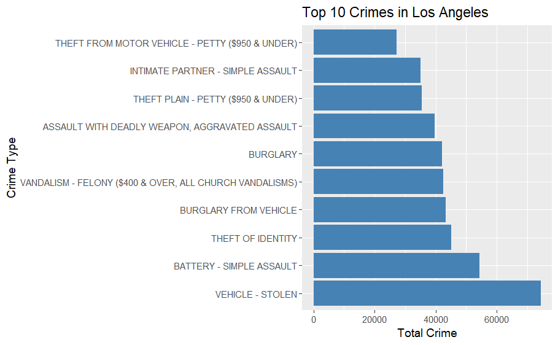

```r
# Plotting crime by type
ggplot(crime_type[1:10,], aes(x = total_crime, y = reorder(`Crm Cd Desc`, -total_crime))) +
  geom_bar(stat = "identity", fill = "steelblue") +
  xlab("Total Crime") + ylab("Crime Type") +
  ggtitle("Top 10 Crimes in Los Angeles")
```

```r
NA
NA
```

The top 10 crime types in Los Angeles were plotted in the graph. The highest Crime is Vehicle Stolen and also Battery Simple Assault.

Analyzed the crime data by location

```r
# crime by location
crime_location <- crime_data %>%
  group_by(`Premis Desc`) %>%
  summarize(total_crime = n()) %>%
  arrange(desc(total_crime))
crime_location
```

| Premis Desc | total_crime |
| --- | --- |
| STREET | 174075 |
| SINGLE FAMILY DWELLING | 117217 |
| MULTI-UNIT DWELLING (APARTMENT, DUPLEX, ETC) | 84686 |
| PARKING LOT | 49521 |
| OTHER BUSINESS | 31959 |
| SIDEWALK | 30067 |
| VEHICLE, PASSENGER/TRUCK | 20916 |
| GARAGE/CARPORT | 14280 |
| DRIVEWAY | 11810 |
| RESTAURANT/FAST FOOD | 8754 |

[output cut: 297 more lines]

```r
NA
```

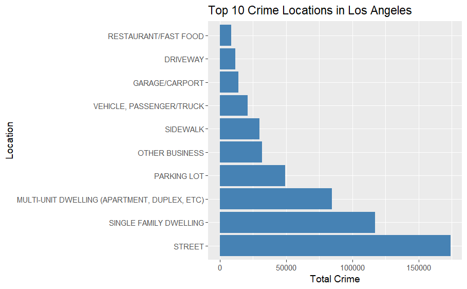

```r
# Plotting crime by location
ggplot(crime_location[1:10,], aes(x = total_crime, y = reorder(`Premis Desc`, -total_crime))) +
  geom_bar(stat = "identity", fill = "steelblue") +
  xlab("Total Crime") + ylab("Location") +
  ggtitle("Top 10 Crime Locations in Los Angeles")
```

This information can be useful for law enforcement agencies to focus their efforts in high-risk areas and work towards reducing crime rates in the city.

Analyzing the number of crimes by each day of the week

```r
# Extracting day of the week from Date Occurred column
crime_data$DayOfWeek <- weekdays(as.Date(crime_data$`DATE OCC`))
```

```r
# Count the number of crimes by day of the week
crimes_by_day <- crime_data %>%
  group_by(DayOfWeek) %>%
  summarise(Count = n()) %>%
  filter(!is.na(DayOfWeek))
crimes_by_day
```

| DayOfWeek | Count |
| --- | --- |
| Friday | 42127 |
| Monday | 36886 |
| Saturday | 40647 |
| Sunday | 41583 |
| Thursday | 40875 |
| Tuesday | 44949 |
| Wednesday | 38059 |

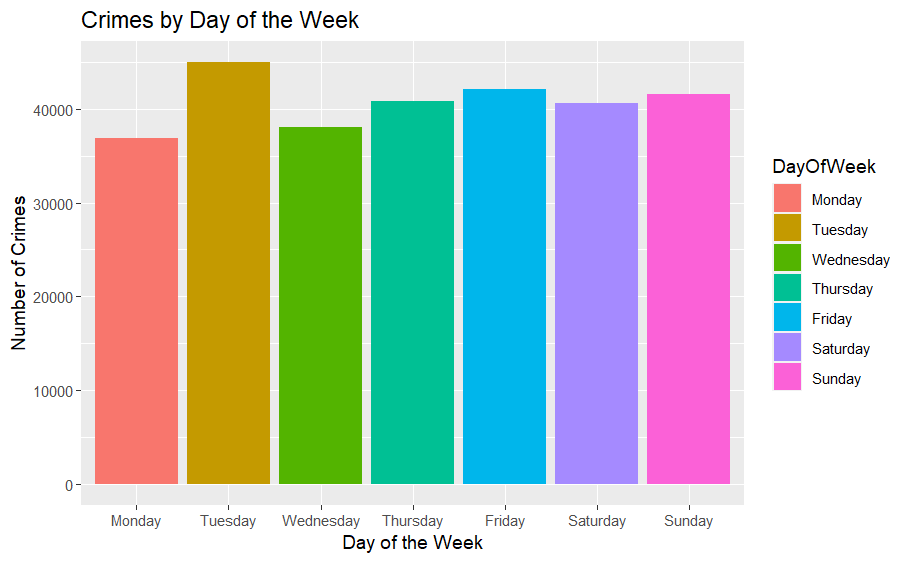

```r
#desired order of the days of the week
desired_order <- c("Monday", "Tuesday", "Wednesday", "Thursday", "Friday", "Saturday", "Sunday")

# Converting the DayOfWeek column to a factor with the desired order
crimes_by_day$DayOfWeek <- factor(crimes_by_day$DayOfWeek, levels = desired_order)

# Creating the bar chart with the updated order of the days of the week
ggplot(crimes_by_day, aes(x = DayOfWeek, y = Count, fill = DayOfWeek)) +
  geom_bar(stat = "identity") +
  labs(x = "Day of the Week", y = "Number of Crimes", title = "Crimes by Day of the Week")
```

The analysis then moves on to examine the differences in crime rates across different parts of the city.

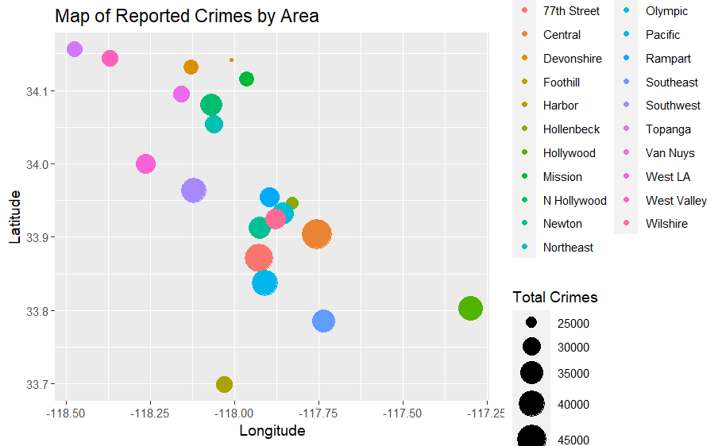

```r
# Differences between parts of town
crime_data %>%
  group_by(`AREA NAME`) %>%
  summarize(total_crimes = n(),
            avg_lat = mean(LAT, na.rm = TRUE),
            avg_lon = mean(LON, na.rm = TRUE))%>%
  ggplot(aes(x = avg_lon, y = avg_lat, size = total_crimes, color = `AREA NAME`)) +
  geom_point() +
  scale_size_continuous(range = c(1, 10)) +
  labs(title = "Map of Reported Crimes by Area",
       x = "Longitude",
       y = "Latitude",
       size = "Total Crimes",
       color = " Area Name")
```

To identify any outliers or unusual patterns in the data and to summarize the status of each crime.

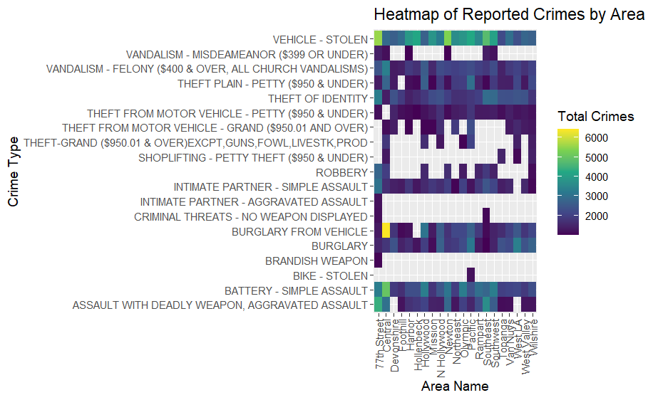

```r
# Looking for outliers and unusual patterns
crime_data %>%
  group_by(`AREA NAME`, `Crm Cd Desc`) %>%
  summarize(total_crimes = n()) %>%
  filter(total_crimes > 1000) %>%
  ggplot(aes(x = `AREA NAME`, y = `Crm Cd Desc`, fill = total_crimes)) +
  geom_tile() +
  theme(axis.text.x=element_text(angle=90, vjust=0.5,hjust=1))+
  scale_fill_viridis_c() +
  labs(title = "Heatmap of Reported Crimes by Area and Type (with Outliers)",
       x = "Area Name",
       y = "Crime Type",
       fill = "Total Crimes")
```

This visualization helps to identify areas and crime types that have a high number of crimes, potentially indicating areas that need more attention from law enforcement agencies.

Analyzing the total number of crimes for each status description in the crime_data dataframe.

```r
# Summarizing the status of each crime using count
crime_status_count <- crime_data %>%
  group_by(`Status Desc`) %>%
  summarise(count = n())
crime_status_count
```

| Status Desc | count |
| --- | --- |
| Adult Arrest | 60242 |
| Adult Other | 74941 |
| Invest Cont | 552013 |
| Juv Arrest | 2141 |
| Juv Other | 1114 |
| UNK | 3 |

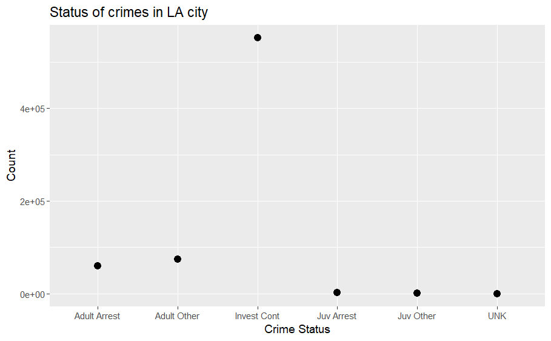

```r
# Visualizing the status of each crime using geom point
ggplot(crime_status_count, aes(x = `Status Desc`, y = count)) +
  geom_point(size = 3) +
  labs(title = "Status of crimes in LA city",
       x = "Crime Status", y = "Count")
```

we can get a summary of the status of each crime in the dataset, such as the number of crimes that were cleared, under investigation, or still open. We can use this information to get a general idea of how many crimes have been resolved and how many are still being investigated or remain unsolved.This information can be used by law enforcement agencies and policymakers to make informed decisions on crime prevention and reduction strategies.

Analyzing to count the number of crimes in each month

```r
# Convert date/time column to a datetime object
crime_data$`Date Rptd` <- lubridate::mdy_hms(crime_data$`Date Rptd`)
```

```r
# Count the number of crimes by month
crime_month_counts <- crime_data %>%
  group_by(month = floor_date(`Date Rptd`, unit = "month")) %>%
  summarize(count = n())
```

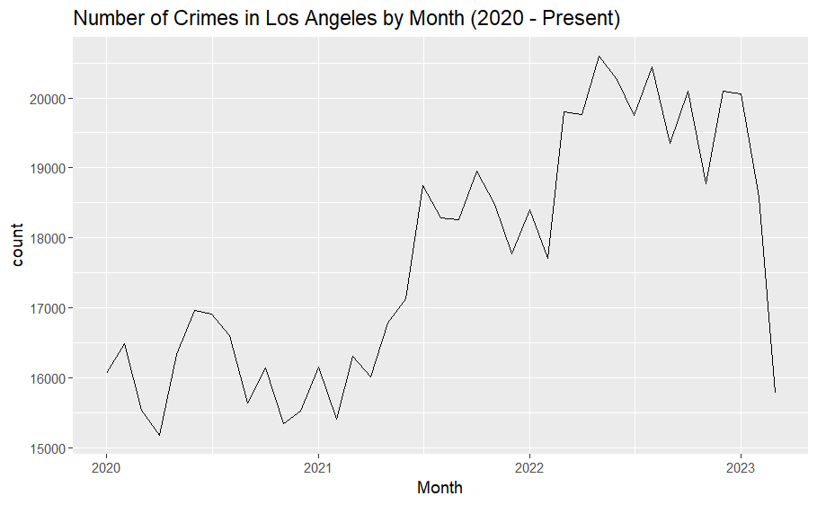

```r
# Creating a line chart of crime trends over time
ggplot(crime_month_counts, aes(x = month, y = count)) +
  geom_line() +
  ggtitle("Number of Crimes in Los Angeles by Month (2020 - Present)") +
  xlab("Month") +
  ylab("count")
```

Analyzing the crimes by date and counts the number of occurrences for each date.

```r
# Converting Date Occurred column to date format
crime_data$`DATE OCC` <- as.Date(crime_data$`DATE OCC`, format = "%m/%d/%Y")
```

```r
# Grouping crimes by date and counting the number of occurrences
crime_count <- crime_data %>%
  group_by(`DATE OCC`) %>%
  summarize(count = n())
crime_count
```

| DATE OCC | count |
| --- | --- |
| 2020-01-01 | 1070 |
| 2020-01-02 | 526 |
| 2020-01-03 | 593 |
| 2020-01-04 | 539 |
| 2020-01-05 | 505 |
| 2020-01-06 | 593 |
| 2020-01-07 | 538 |
| 2020-01-08 | 536 |
| 2020-01-09 | 572 |
| 2020-01-10 | 625 |

[output cut: 990 more lines]

```r
NA
```

```r
# Creating a dygraph of the crime counts over time
dygraph(crime_count, xlab = "Date", ylab = "Number of Crimes") %>%
  dyRangeSelector() %>%
  dySeries("count", label = "Crimes") %>%
  dyOptions(stackedGraph = TRUE)
```

[interactive chart not shown]

```r
NA
```

visual representation of the top 10 areas with the highest crime rates in Los Angeles

```r
# Count the number of crimes in each area and select the top 10
top_10_areas <- crime_data %>%
  group_by(`AREA NAME`) %>%
  summarise(total_crimes = n()) %>%
  top_n(10, n) %>%
  arrange(desc(total_crimes))
top_10_areas
```

| AREA NAME | total_crimes |
| --- | --- |
| Central | 46118 |
| 77th Street | 43776 |
| Pacific | 39776 |
| Southwest | 38762 |
| Hollywood | 37113 |
| Southeast | 35527 |
| Olympic | 34645 |
| N Hollywood | 34458 |
| Newton | 34343 |
| Wilshire | 32542 |

[output cut: 11 more lines]

```r
# Create a dataframe with the place names and their longitude/latitude values
places <- data.frame(place = c("Central", "77th Street", "Pacific", "Southwest", "Hollywood", "Southeast", "Olympic", "N Hollywood", "Newton", "Wilshire"),
                     latitude = c(34.0537, 33.9716, 33.9519, 34.0039, 34.0928, 33.9440, 34.0522, 34.1870, 33.9897, 34.0639),
                     longitude = c(-118.2427, -118.2731, -118.3965, -118.3080, -118.3287, -118.2468, -118.2837, -118.3813, -118.2567, -118.3602))
places
```

| place | latitude | longitude |
| --- | --- | --- |
| Central | 34.0537 | -118.2427 |
| 77th Street | 33.9716 | -118.2731 |
| Pacific | 33.9519 | -118.3965 |
| Southwest | 34.0039 | -118.3080 |
| Hollywood | 34.0928 | -118.3287 |
| Southeast | 33.9440 | -118.2468 |
| Olympic | 34.0522 | -118.2837 |
| N Hollywood | 34.1870 | -118.3813 |
| Newton | 33.9897 | -118.2567 |
| Wilshire | 34.0639 | -118.3602 |

```r
NA
```

```r
# Create the leaflet map
m <- leaflet(places) %>%
  addTiles() %>%
  setView(lng = -118.3, lat = 34, zoom = 10)

# Add markers for the places
m <- m %>%
  addMarkers(lng = ~longitude, lat = ~latitude, popup = ~place)
m
```

[interactive chart not shown]

```r
NA
```

Here Markers are added to the map to show the location of each area. Clicking on a marker shows the name of the area in a popup window. The resulting map gives a visual representation of the top 10 areas with the highest crime rates in Los Angeles.

Overall, this analysis provides valuable insights into the distribution of crime in Los Angeles and can help policymakers and law enforcement agencies to better understand and address crime in the city.

# **Conclusion**

Based on the different analyses conducted, it can be concluded that there are specific crime types, locations, days of the week, and areas in Los Angeles that have a higher frequency of reported crimes. Law enforcement agencies and policymakers can use this information to implement targeted interventions and prevention strategies to reduce crime rates in the city. Overall, this analysis provides valuable insights into the distribution of crime in Los Angeles and can serve as a foundation for future research and policy decisions to enhance public safety in the city.

# **Future Scope**

The further analysis for this analysis will be Demographic Analysis.

Analyzing the demographic data available in the dataset could provide insights into the disparities and patterns in the involvement of different races, ethnicities, and genders in various types of crimes. By examining this information, we could potentially uncover patterns that may help address issues related to social justice and inequality.

For example, we could explore whether certain races or ethnicities are overrepresented as victims or suspects in particular types of crimes. We could also investigate whether there are any gender-based disparities in the commission or victimization of certain crimes. By analyzing this data, we could potentially identify any biases or injustices in the criminal justice system and work towards addressing them.